# MoveBank Env-DATA

## Intro

Script for accessing Movebank [Env-DATA annotation service](https://www.movebank.org/cms/movebank-content/env-data). The code is built upon examples from Elie’s [ABoVE](https://github.com/ABoVE-AotM/above) and other movebank related tutorials like `Bald Eagle Code Example` by `Mariëlle van Toor`.

## Script

```r
if (!require("pacman")) install.packages("pacman")
```

```r
pacman::p_load(purrr, stringr, lubridate, data.table, glue, XML, RCurl, ggplot2, maps)
# path for these tasks
task_folder <- "env_data"
source(file.path(task_folder, "R", "EnvDATA.R"))
```

### 1. Creating the data file

The data file has to be a text csv with several constraints on the formatting: - The columns must be titled: timestamp,location-long,location-lat,height-above-ellipsoid - The time stamps MUST look like this: 2007-04-20 0:00:00.000. They will be interpreted as UTC - Latitude and Longitude coordinates are in WGS84 - Height above ellipsoid is in m. - Null values should be left blank. You will get errors if you use capital letters, spaces, quotations, or leave out the decimal seconds in the timestamps.

- [] column title become location.long after data.frame make.names? which one?
- all the dateframe function do is set names and conver time. in most case we should have data in dataframe, just need to make sure the name mapping, then convert a data frame directly. take a data frame and mapping vector. a name vector is easier to write, but need to make sure about order. no need to spend too much time on this now.
- grid is lon/lat/timestamp vector combination. give range of each one.

```r
library(ctmm)
# track annotation
data(buffalo)
df <- data.frame(buffalo[[1]])
existing_names <- c("timestamp", "longitude", "latitude")
dt <- to_env_dataframe(df, existing_names)
```

```r
# grid annotation
lats <- seq(38.8, 39.0, length = 40)
lons <- seq(-77.12, -76.91, length = 40)
# times need to be POSIXct, not Date
start <- ymd_hms("2014-01-01 0:00:00")
finish <- ymd_hms("2014-12-31 0:00:00")
timestep <- ddays(20)
times <- seq(start, finish, by = timestep)
test_grid <- create_data_grid(lats, lons, times)
grid_path <- file.path(task_folder, "data", "DC2014grid.csv")
fwrite(test_grid, grid_path)
```

### 2. Creating the XML request file

- the request_name is just a name you come up with
- type_name comes from the [list of available services](http://www.bioinfo.mpg.de/orn-gateway/services2.jsp). They must be entered exactly as seen with no spaces. Here we’re using the MODIS land 13AQ1 products.
  - variable_name is the specific data we are interested in, inside of the relevant folder
- [interpolation_type](https://www.movebank.org/node/6400). Basically - if there are potential gaps (as in MODIS) the “inverse-distance-weighted” is your best bet. Other options are “bilinear” and “nearest-neighbor”.
- dist_func_spatial is the function used for distance computation … the “geodetic” default is probably generally fine.
- email is the email address that a notification will be sent to you
- [] verify the type_name and variable_name. These can change so better verify before sending request, otherwise request will fail. can be an option, default on, can be turned off for faster if user want. use an options value, which should be valid for one session but reset for next. options(check_variable = TRUE) options(“check_variable”)
- [] current this is just for grid. change name to match it
  - should support multiple variables in one request
  - support output format
    - split tiles

```r
request_path <- file.path(task_folder, "data", "DC2014request.xml")
create_request(request_name = "DC2014request-3",
               type_name = "modis-land/MOD13A1.006",
               variable_name =   "500m 16 days NDVI",
               interpolation_type = "inverse-distance-weighted",
               dist_func_spatial = "geodetic",
               email = "xhdong@umd.edu",
               save_to_path = request_path)
```

```
## [1] "env_data/data/DC2014request.xml"
```

### 3. Upload the data and request

```r
status_link <- file.path(task_folder, "data", "DCstatus.url")
DC2014status <- upload_request(csv_path = grid_path,
                     xml_path = request_path,
                     login = Sys.getenv("movebank_envdata_user"),
                     password = Sys.getenv("movebank_envdata_pass"),
                     link_path = status_link)
# save for development
# saveRDS(DC2014status, file = file.path(task_folder, "data", "DC2014status.rds"))
```

### 4. Downloading the annotated data

- Result will be kept for 1 week after finished. User will receive email when the task was finished. The status link can show status and user can download from there too.

```r
result_path <- file.path(task_folder, "data", "DC2014.ndvi.csv")
download_result(DC2014status, file_path = result_path)
```

### 5. Visualizing

- The code example I have for backend service only support grid request, which submit a grid csv and get a csv back. The web page support raster result, we will try to add support for raster request after contacting Movebank for documentation.

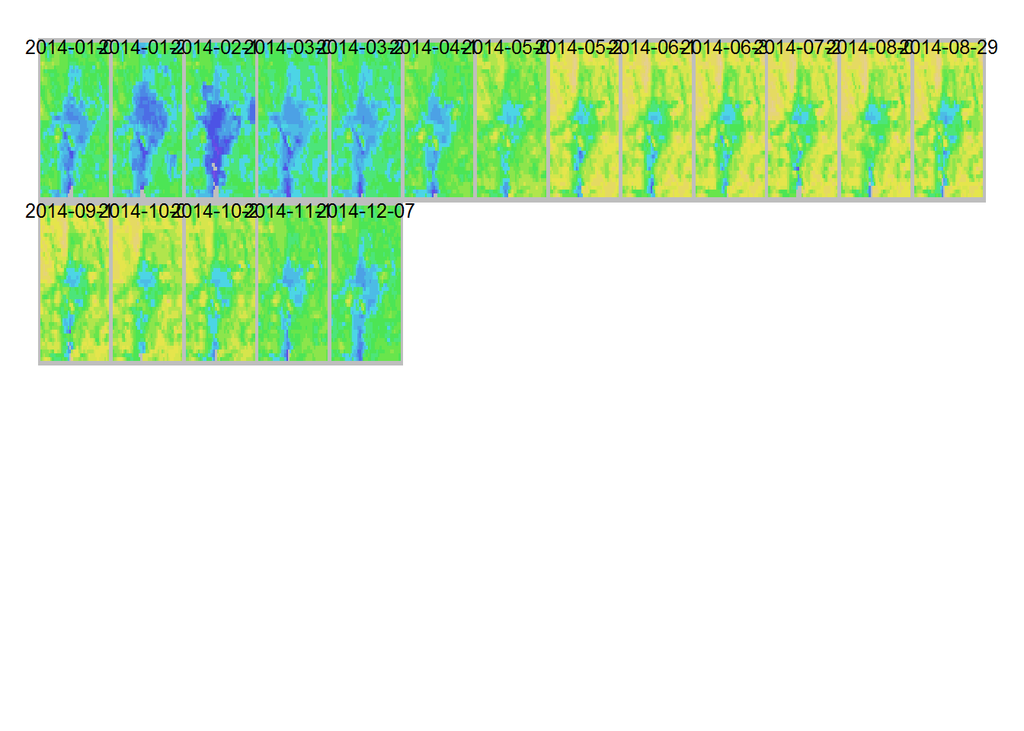

```r
# we don't want to submit annotation request in every run, so previous result are saved.
# load result
result_path <- file.path(task_folder, "data", "DC2014.ndvi.csv")
DC2014.ndvi <- fread(result_path)

# simplify names and modify table
names(DC2014.ndvi) <- c("time", "lon", "lat", "height", "ndvi")
DC2014.ndvi[, `:=`(lat = round(lat, 5),
                   lon = round(lon, 5),
                   day = as.Date(DC2014.ndvi$time))]


# set range and breakes
ndvi.range <- range(DC2014.ndvi$ndvi)
breaks <- seq(-.2, 1, length=21)
times <- unique(DC2014.ndvi$time)

lats <- unique(DC2014.ndvi$lat) %>% sort
lons <- unique(DC2014.ndvi$lon) %>% sort
par(mar = c(0,0,0,0), mfrow = c(4,13), oma = c(2,2,2,2))
for(i in 1:length(times[-1])){ #for each distinct time
  ndvi.today <- subset(DC2014.ndvi, time == times[i]) #ndvi.today = the NDVI for that time
  M.ndvi.today <- t(matrix(ndvi.today$ndvi, nrow = length(lats)))
  plot.new(); plot.window(xlim = range(lons), ylim = range(lats))
  maps::map("world", xlim = range(lons), ylim = range(lats), fill=TRUE, col="grey", add=TRUE)
  image(lons, lats, M.ndvi.today, col=topo.colors(20, alpha = 0.6), add=TRUE, breaks = breaks)
    mtext(side = 3, as.Date(times[i]), line = -1, cex=0.8)
}
```